# Introduction to Neural Networks: Bank Churn Prediction Porject 7

## November 2022

## Problem Statement

"Given a Bank customer, build a neural network-based classifier that can determine whether they will leave or not in the next 6 months."

## Data Dictionary

- CustomerId: Unique ID which is assigned to each customer
- Surname: Last name of the customer
- CreditScore: It defines the credit history of the customer.
- Geography: A customer’s location
- Gender: It defines the Gender of the customer
- Age: Age of the customer
- Tenure: Number of years for which the customer has been with the bank
- NumOfProducts: It refers to the number of products that a customer has purchased through the bank.
- Balance: Account balance
- HasCrCard: It is a categorical variable that decides whether the customer has a credit card or not.
- EstimatedSalary: Estimated salary
- isActiveMember: It is a categorical variable that decides whether the customer is an active member of the bank or not ( Active member in the sense, using bank products regularly, making transactions, etc )
- Exited: It is a categorical variable that decides whether the customer left the bank within six months or not. It can take two values

  ```
                0=No ( Customer did not leave the bank )

                1=Yes ( Customer left the bank )
  ```

## Section 1:Exploratory Data Analysis

- Define problem statement - Read the dataset
- Print the overview of the data (statistical summary, shape, info, etc)
- Eliminate the unique features from the dataset with proper reasoning
- Univariate analysis
- Bivariate analysis

Note: Reusing code from previous projects!!

```python
# Libraries to help with reading and manipulating data
import numpy as np
import pandas as pd
# libaries to help with data visualization
import matplotlib.pyplot as pyplot
import matplotlib.pyplot as plt
import seaborn as sns
# Library to split data
from sklearn.model_selection import train_test_split
# library to import to standardize the data
from sklearn.preprocessing import StandardScaler
#To import different metrics
from sklearn.metrics import explained_variance_score, mean_squared_error, r2_score, mean_absolute_error
#Importing classback API
from keras import callbacks
# Importing tensorflow library
import tensorflow as tf
# importing different functions to build models
from tensorflow.keras.layers import Dense, Dropout,InputLayer
from tensorflow.keras.models import Sequential
# Importing Batch Normalization
from keras.layers import BatchNormalization
# Importing backend
from tensorflow.keras import backend
# Importing shffule
from random import shuffle
from keras.callbacks import ModelCheckpoint
# Importing optimizers
from tensorflow.keras.optimizers import Adam
from tensorflow.keras.optimizers import RMSprop
# Library to avoid the warnings
import warnings
warnings.filterwarnings("ignore")
```

```python
#Read CSV
data = pd.read_csv("Churn.csv")
data.head()
```

|  | RowNumber | CustomerId | Surname | CreditScore | Geography | Gender | Age | Tenure | Balance | NumOfProducts | HasCrCard | IsActiveMember | EstimatedSalary | Exited |
| --- | --- | --- | --- | --- | --- | --- | --- | --- | --- | --- | --- | --- | --- | --- |
| 0 | 1 | 15634602 | Hargrave | 619 | France | Female | 42 | 2 | 0.00 | 1 | 1 | 1 | 101348.88 | 1 |
| 1 | 2 | 15647311 | Hill | 608 | Spain | Female | 41 | 1 | 83807.86 | 1 | 0 | 1 | 112542.58 | 0 |
| 2 | 3 | 15619304 | Onio | 502 | France | Female | 42 | 8 | 159660.80 | 3 | 1 | 0 | 113931.57 | 1 |
| 3 | 4 | 15701354 | Boni | 699 | France | Female | 39 | 1 | 0.00 | 2 | 0 | 0 | 93826.63 | 0 |
| 4 | 5 | 15737888 | Mitchell | 850 | Spain | Female | 43 | 2 | 125510.82 | 1 | 1 | 1 | 79084.10 | 0 |

```python
#Make a back-up copy of original dataset
data_copy=data.copy()
```

```python
# Display 10 random rows
np.random.seed(1)
data.sample(n=10)
```

|  | RowNumber | CustomerId | Surname | CreditScore | Geography | Gender | Age | Tenure | Balance | NumOfProducts | HasCrCard | IsActiveMember | EstimatedSalary | Exited |
| --- | --- | --- | --- | --- | --- | --- | --- | --- | --- | --- | --- | --- | --- | --- |
| 9953 | 9954 | 15655952 | Burke | 550 | France | Male | 47 | 2 | 0.00 | 2 | 1 | 1 | 97057.28 | 0 |
| 3850 | 3851 | 15775293 | Stephenson | 680 | France | Male | 34 | 3 | 143292.95 | 1 | 1 | 0 | 66526.01 | 0 |
| 4962 | 4963 | 15665088 | Gordon | 531 | France | Female | 42 | 2 | 0.00 | 2 | 0 | 1 | 90537.47 | 0 |
| 3886 | 3887 | 15720941 | Tien | 710 | Germany | Male | 34 | 8 | 147833.30 | 2 | 0 | 1 | 1561.58 | 0 |
| 5437 | 5438 | 15733476 | Gonzalez | 543 | Germany | Male | 30 | 6 | 73481.05 | 1 | 1 | 1 | 176692.65 | 0 |
| 8517 | 8518 | 15671800 | Robinson | 688 | France | Male | 20 | 8 | 137624.40 | 2 | 1 | 1 | 197582.79 | 0 |
| 2041 | 2042 | 15709846 | Yeh | 840 | France | Female | 39 | 1 | 94968.97 | 1 | 1 | 0 | 84487.62 | 0 |
| 1989 | 1990 | 15622454 | Zaitsev | 695 | Spain | Male | 28 | 0 | 96020.86 | 1 | 1 | 1 | 57992.49 | 0 |
| 1933 | 1934 | 15815560 | Bogle | 666 | Germany | Male | 74 | 7 | 105102.50 | 1 | 1 | 1 | 46172.47 | 0 |
| 9984 | 9985 | 15696175 | Echezonachukwu | 602 | Germany | Male | 35 | 7 | 90602.42 | 2 | 1 | 1 | 51695.41 | 0 |

```python
data.info()
```

```
<class 'pandas.core.frame.DataFrame'>
RangeIndex: 10000 entries, 0 to 9999
Data columns (total 14 columns):
 #   Column           Non-Null Count  Dtype
---  ------           --------------  -----
 0   RowNumber        10000 non-null  int64
 1   CustomerId       10000 non-null  int64
 2   Surname          10000 non-null  object
 3   CreditScore      10000 non-null  int64
 4   Geography        10000 non-null  object
 5   Gender           10000 non-null  object
 6   Age              10000 non-null  int64
 7   Tenure           10000 non-null  int64
 8   Balance          10000 non-null  float64
 9   NumOfProducts    10000 non-null  int64
 10  HasCrCard        10000 non-null  int64
 11  IsActiveMember   10000 non-null  int64
 12  EstimatedSalary  10000 non-null  float64
 13  Exited           10000 non-null  int64
dtypes: float64(2), int64(9), object(3)
memory usage: 1.1+ MB
```

```python
# of rows and columns
print(f'There are {data.shape[0]} rows and {data.shape[1]} columns.')
```

```
There are 10000 rows and 14 columns.
```

```python
# Check for null values in dataset
data.isnull().sum()
```

```
RowNumber          0
CustomerId         0
Surname            0
CreditScore        0
Geography          0
Gender             0
Age                0
Tenure             0
Balance            0
NumOfProducts      0
HasCrCard          0
IsActiveMember     0
EstimatedSalary    0
Exited             0
dtype: int64
```

```python
# Understand the number of unique values in each column
data.nunique()
```

```
RowNumber          10000
CustomerId         10000
Surname             2932
CreditScore          460
Geography              3
Gender                 2
Age                   70
Tenure                11
Balance             6382
NumOfProducts          4
HasCrCard              2
IsActiveMember         2
EstimatedSalary     9999
Exited                 2
dtype: int64
```

```python
#Check for duplicates
data[data.duplicated()].count()
```

```
RowNumber          0
CustomerId         0
Surname            0
CreditScore        0
Geography          0
Gender             0
Age                0
Tenure             0
Balance            0
NumOfProducts      0
HasCrCard          0
IsActiveMember     0
EstimatedSalary    0
Exited             0
dtype: int64
```

```python
#Understand the number of each value for the following categorical columns:
cat_cols=['Geography','Gender','Tenure','NumOfProducts','HasCrCard','IsActiveMember','Exited']
for col in cat_cols:
    print(data[col].value_counts())
    print("_________________________________")
```

```
France     5014
Germany    2509
Spain      2477
Name: Geography, dtype: int64
_________________________________
Male      5457
Female    4543
Name: Gender, dtype: int64
_________________________________
2     1048
1     1035
7     1028
8     1025
5     1012
3     1009
4      989
9      984
6      967
10     490
0      413
Name: Tenure, dtype: int64
_________________________________
1    5084
2    4590
3     266
4      60
Name: NumOfProducts, dtype: int64
_________________________________
1    7055
0    2945
Name: HasCrCard, dtype: int64
_________________________________
1    5151
0    4849
Name: IsActiveMember, dtype: int64
_________________________________
0    7963
1    2037
Name: Exited, dtype: int64
_________________________________
```

```python
#Understand the number of each value for the following categorical columns:
cat_cols=['Geography','Gender','Tenure','NumOfProducts','HasCrCard','IsActiveMember','Exited']
for col in cat_cols:
    print(data[col].value_counts(normalize=True)*100)
    print("_________________________________")
```

```
France     50.14
Germany    25.09
Spain      24.77
Name: Geography, dtype: float64
_________________________________
Male      54.57
Female    45.43
Name: Gender, dtype: float64
_________________________________
2     10.48
1     10.35
7     10.28
8     10.25
5     10.12
3     10.09
4      9.89
9      9.84
6      9.67
10     4.90
0      4.13
Name: Tenure, dtype: float64
_________________________________
1    50.84
2    45.90
3     2.66
4     0.60
Name: NumOfProducts, dtype: float64
_________________________________
1    70.55
0    29.45
Name: HasCrCard, dtype: float64
_________________________________
1    51.51
0    48.49
Name: IsActiveMember, dtype: float64
_________________________________
0    79.63
1    20.37
Name: Exited, dtype: float64
_________________________________
```

```python
# Calculate Descriptive stats
data.describe().T
```

|  | count | mean | std | min | 25% | 50% | 75% | max |
| --- | --- | --- | --- | --- | --- | --- | --- | --- |
| RowNumber | 10000.0 | 5.000500e+03 | 2886.895680 | 1.00 | 2500.75 | 5.000500e+03 | 7.500250e+03 | 10000.00 |
| CustomerId | 10000.0 | 1.569094e+07 | 71936.186123 | 15565701.00 | 15628528.25 | 1.569074e+07 | 1.575323e+07 | 15815690.00 |
| CreditScore | 10000.0 | 6.505288e+02 | 96.653299 | 350.00 | 584.00 | 6.520000e+02 | 7.180000e+02 | 850.00 |
| Age | 10000.0 | 3.892180e+01 | 10.487806 | 18.00 | 32.00 | 3.700000e+01 | 4.400000e+01 | 92.00 |
| Tenure | 10000.0 | 5.012800e+00 | 2.892174 | 0.00 | 3.00 | 5.000000e+00 | 7.000000e+00 | 10.00 |
| Balance | 10000.0 | 7.648589e+04 | 62397.405202 | 0.00 | 0.00 | 9.719854e+04 | 1.276442e+05 | 250898.09 |
| NumOfProducts | 10000.0 | 1.530200e+00 | 0.581654 | 1.00 | 1.00 | 1.000000e+00 | 2.000000e+00 | 4.00 |
| HasCrCard | 10000.0 | 7.055000e-01 | 0.455840 | 0.00 | 0.00 | 1.000000e+00 | 1.000000e+00 | 1.00 |
| IsActiveMember | 10000.0 | 5.151000e-01 | 0.499797 | 0.00 | 0.00 | 1.000000e+00 | 1.000000e+00 | 1.00 |
| EstimatedSalary | 10000.0 | 1.000902e+05 | 57510.492818 | 11.58 | 51002.11 | 1.001939e+05 | 1.493882e+05 | 199992.48 |
| Exited | 10000.0 | 2.037000e-01 | 0.402769 | 0.00 | 0.00 | 0.000000e+00 | 0.000000e+00 | 1.00 |

### Data Dictionary and initial comments

- CustomerId: Unique ID which is assigned to each customer
  - Likely this feature is non - informative for the model and should be dropped;
- Surname: Last name of the customer
  - Likely this variable is non-informative for the model and should be dropped
- CreditScore: It defines the credit history of the customer.
  - Values range between 350 and 850 with mean of 651 and median of 652 indicating that the credit score data is likely not skewed
  - Need to explore distribution of data and feature relationships
- Geography: A customer’s location
  - Customers reside France (50%), Germany(25%)and Spain(25%)
- Gender: It defines the Gender of the customer
  - 55% Male
  - 45% Female
- Age: Age of the customer
  - Values range between 18 and 92 with mean of 39 and median of 37; data may be slightly skewed
- Tenure: Number of years for which the customer has been with the bank
  - Values range from 0 to 10 with meand of 5 years and median of 5 years; data is likely not skewed but appears to be categorical and evenly spread acrosso all teunure values from 1-9 inclusive (with smaller number of customes with tenure of 10 years)
- NumOfProducts: It refers to the number of products that a customer has purchased through the bank.
  - Values are integegers from 1-4, with 97% of customer utilizes 1 or 2 products (51% use 1 product, 46% use 2 products )
- Balance: Account balance
  - values range from 0 to 251,000 with mean of 76000 and median 97000;
  - data is likely heavily skewed distribution
- HasCrCard: It is a categorical variable that decides whether the customer has a credit card or not.
  - 71% have credit card
  - 29% do not have credit card
- EstimatedSalary: Estimated salary
  - values range from practically 0 to 200000 with mean of 100000 and median of 100000; data is likely not skewed
- isActiveMember: It is a categorical variable that decides whether the customer is an active member of the bank or not ( Active member in the sense, using bank products regularly, making transactions, etc )
  - 52% of members are active
  - 48% of members are not active
- Exited: It is a categorical variable that decides whether the customer left the bank within six months or not. It can take two values
  - This variable is the churn rate
  - 80% of customers did not exit (did not churn)
  - 20% of customers did exit (did churn)

```python
# From Anime Rating Prediction case study, function to plot a boxplot and a histogram along the same scale.


def histogram_boxplot(data, feature, figsize=(12, 7), kde=False, bins=None):
    """
    Boxplot and histogram combined

    data: dataframe
    feature: dataframe column
    figsize: size of figure (default (12,7))
    kde: whether to the show density curve (default False)
    bins: number of bins for histogram (default None)
    """
    f2, (ax_box2, ax_hist2) = plt.subplots(
        nrows=2,  # Number of rows of the subplot grid= 2
        sharex=True,  # x-axis will be shared among all subplots
        gridspec_kw={"height_ratios": (0.25, 0.75)},
        figsize=figsize,
    )  # creating the 2 subplots
    sns.boxplot(
        data=data, x=feature, ax=ax_box2, showmeans=True, color="violet"
    )  # boxplot will be created and a star will indicate the mean value of the column
    sns.histplot(
        data=data, x=feature, kde=kde, ax=ax_hist2, bins=bins, palette="winter"
    ) if bins else sns.histplot(
        data=data, x=feature, kde=kde, ax=ax_hist2
    )  # For histogram
    ax_hist2.axvline(
        data[feature].mean(), color="green", linestyle="--"
    )  # Add mean to the histogram
    ax_hist2.axvline(
        data[feature].median(), color="black", linestyle="-"
    )  # Add median to the histogram
```

```python
#from Flight Price Botebook
# function to create labeled barplots (with added "hue")


def labeled_barplot(data, feature, perc=False, n=None, hue='Exited'):
    """
    Barplot with percentage at the top

    data: dataframe
    feature: dataframe column
    perc: whether to display percentages instead of count (default is False)
    n: displays the top n category levels (default is None, i.e., display all levels)
    """

    total = len(data[feature])  # length of the column
    count = data[feature].nunique()
    if n is None:
        plt.figure(figsize=(count + 1, 5))
    else:
        plt.figure(figsize=(n + 1, 5))

    plt.xticks(rotation=90, fontsize=15)
    ax = sns.countplot(
        data=data,
        x=feature,
        hue=hue,
        palette="Paired",
        order=data[feature].value_counts().index[:n].sort_values(),
    )

    for p in ax.patches:
        if perc == True:
            label = "{:.1f}%".format(
                100 * p.get_height() / total
            )  # percentage of each class of the category
        else:
            label = p.get_height()  # count of each level of the category

        x = p.get_x() + p.get_width() / 2  # width of the plot
        y = p.get_height()  # height of the plot

        ax.annotate(
            label,
            (x, y),
            ha="center",
            va="center",
            size=12,
            xytext=(0, 5),
            textcoords="offset points",
        )  # annotate the percentage

    plt.show()  # show the plot
```

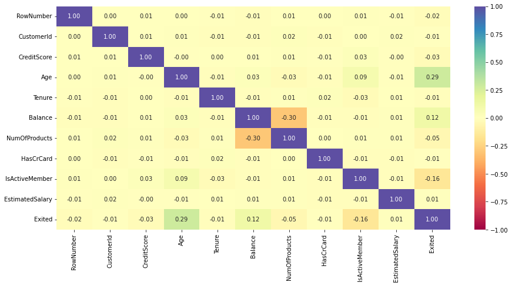

```python
plt.figure(figsize=(15, 7))
sns.heatmap(
    data.corr(), annot=True, vmin=-1, vmax=1, fmt=".2f", cmap="Spectral"
)
plt.show()
```

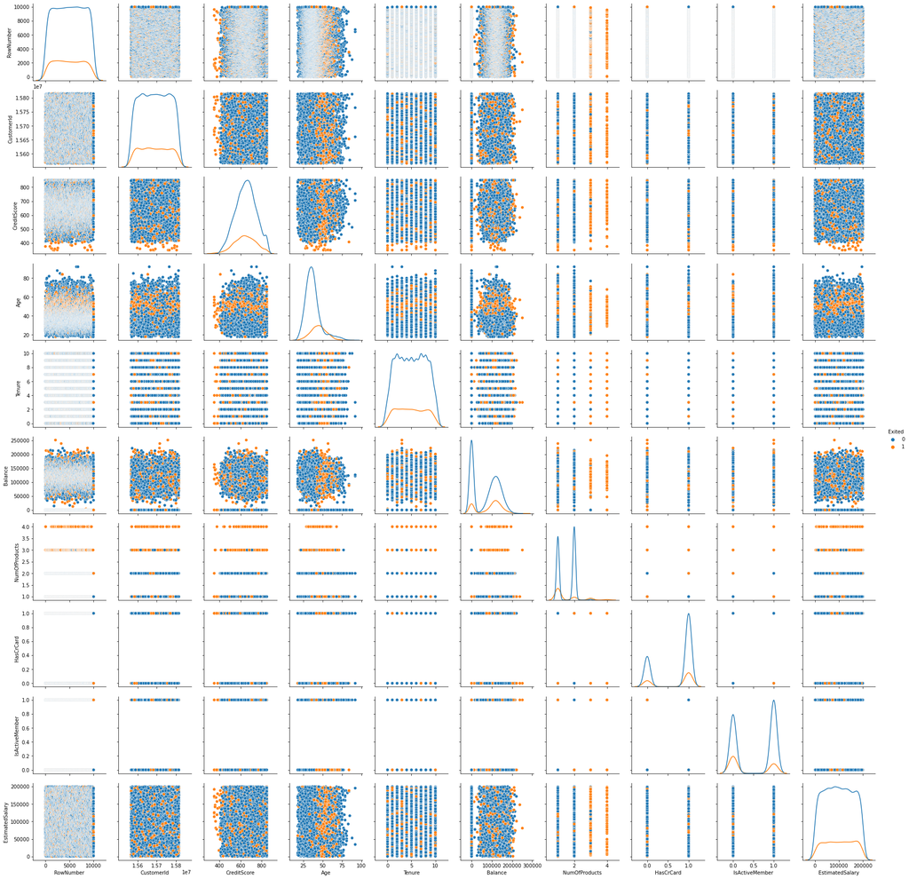

```python
sns.pairplot(data ,hue='Exited', diag_kind = 'kde',diag_kws=dict(fill=False))
plt.show()
```

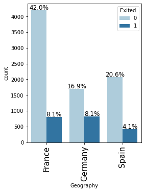

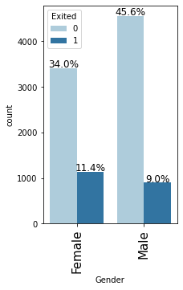

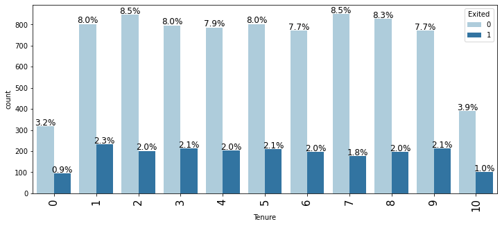

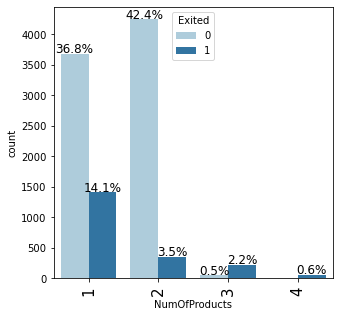

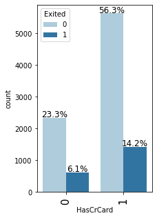

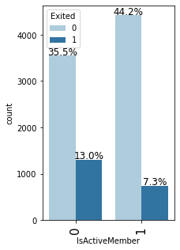

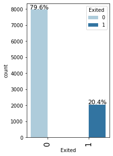

```python
# Bar plots of categorical variables
for col in cat_cols:
    labeled_barplot(data, col, perc=True)
```

```python
# designate numerical columns
num_cols = ['CreditScore','Age','Balance','EstimatedSalary']
```

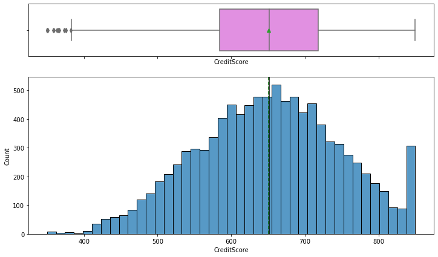

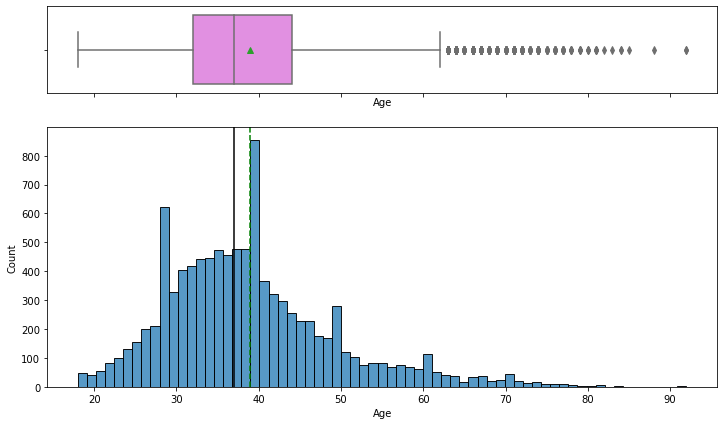

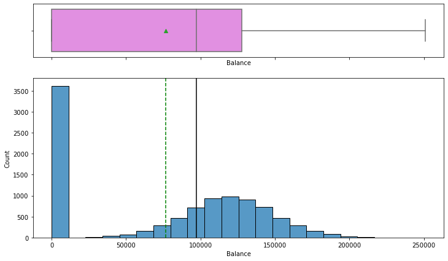

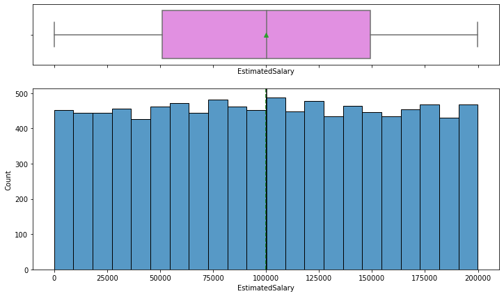

```python
for col in num_cols:
    histogram_boxplot(data, col)
```

```python
data["Exited"] = data["Exited"].astype("category")
```

```python
%matplotlib inline
```

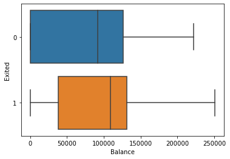

```python
sns.boxplot(data=data, x='Balance', y='Exited')
```

```python
data.groupby('Exited')['Balance'].median()
```

```
Exited
0     92072.68
1    109349.29
Name: Balance, dtype: float64
```

```python
ZeroBalance=data.loc[(data['Balance']==0)]
```

```python
ZeroBalance.info()
```

```
<class 'pandas.core.frame.DataFrame'>
Int64Index: 3617 entries, 0 to 9997
Data columns (total 14 columns):
 #   Column           Non-Null Count  Dtype
---  ------           --------------  -----
 0   RowNumber        3617 non-null   int64
 1   CustomerId       3617 non-null   int64
 2   Surname          3617 non-null   object
 3   CreditScore      3617 non-null   int64
 4   Geography        3617 non-null   object
 5   Gender           3617 non-null   object
 6   Age              3617 non-null   int64
 7   Tenure           3617 non-null   int64
 8   Balance          3617 non-null   float64
 9   NumOfProducts    3617 non-null   int64
 10  HasCrCard        3617 non-null   int64
 11  IsActiveMember   3617 non-null   int64
 12  EstimatedSalary  3617 non-null   float64
 13  Exited           3617 non-null   category
dtypes: category(1), float64(2), int64(8), object(3)
memory usage: 399.3+ KB
```

```python
ZeroBalance.groupby('Exited')['Balance'].count()
```

```
Exited
0    3117
1     500
Name: Balance, dtype: int64
```

## Section 2: EDA Insights

- Identify key meaningful observations on individual variables and the relationship between variables. #### Correlation (from correlation matrix)
- Number of products and Balance are slightly correlated
- Age and Exited are slightly correlated
- Is active member and Exited are very slightly correlated

## Section 3: Data Pre-processing

- Drop non - informative columns
- Split the target variable and predictors
- Split the data into train and test
- Categorical Encoding
- Normalize the data

### Data Preprocessing tasks

- Remove Row Number and CustomerID and Surname features
- Change data types of num and cat columns
- Split data
- Change cat_cols to categoricial variables and apply one-hot encoding
- Normalize num_cols

```python
#Remove Row Number and CustomerID features
data.drop(['RowNumber','CustomerId', 'Surname'], axis=1, inplace = True)
```

```python
data.info()
```

```
<class 'pandas.core.frame.DataFrame'>
RangeIndex: 10000 entries, 0 to 9999
Data columns (total 11 columns):
 #   Column           Non-Null Count  Dtype
---  ------           --------------  -----
 0   CreditScore      10000 non-null  int64
 1   Geography        10000 non-null  object
 2   Gender           10000 non-null  object
 3   Age              10000 non-null  int64
 4   Tenure           10000 non-null  int64
 5   Balance          10000 non-null  float64
 6   NumOfProducts    10000 non-null  int64
 7   HasCrCard        10000 non-null  int64
 8   IsActiveMember   10000 non-null  int64
 9   EstimatedSalary  10000 non-null  float64
 10  Exited           10000 non-null  category
dtypes: category(1), float64(2), int64(6), object(2)
memory usage: 791.3+ KB
```

```python
data[cat_cols] = data[cat_cols].astype('category')
```

```python
data.info()
```

```
<class 'pandas.core.frame.DataFrame'>
RangeIndex: 10000 entries, 0 to 9999
Data columns (total 11 columns):
 #   Column           Non-Null Count  Dtype
---  ------           --------------  -----
 0   CreditScore      10000 non-null  int64
 1   Geography        10000 non-null  category
 2   Gender           10000 non-null  category
 3   Age              10000 non-null  int64
 4   Tenure           10000 non-null  category
 5   Balance          10000 non-null  float64
 6   NumOfProducts    10000 non-null  category
 7   HasCrCard        10000 non-null  category
 8   IsActiveMember   10000 non-null  category
 9   EstimatedSalary  10000 non-null  float64
 10  Exited           10000 non-null  category
dtypes: category(7), float64(2), int64(2)
memory usage: 382.2 KB
```

```python
## Separating Independent and Dependent Columns
X = data.drop(['Exited'],axis=1)
Y = data[['Exited']]
```

```python
# viewing results from above
Y.head()
```

|  | Exited |
| --- | --- |
| 0 | 1 |
| 1 | 0 |
| 2 | 1 |
| 3 | 0 |
| 4 | 0 |

```python
# Generate the testing set.
X_temp, X_test, y_temp, y_test = train_test_split(X,Y, test_size = 0.1, random_state = 5,shuffle = True)
```

```python
# Splitting the dataset into the Training and validation set.
X_train, X_val, y_train, y_val = train_test_split(X_temp,y_temp, test_size = 0.3, random_state = 5,shuffle = True)
```

```python
X_train.shape
```

```
(6300, 10)
```

```python
X_test.shape
```

```
(1000, 10)
```

```python
X_val.shape
```

```
(2700, 10)
```

```python
## Scaling the data
sc=StandardScaler()
temp = sc.fit(X_train[['CreditScore','Age','Balance','EstimatedSalary']])
```

```python
X_train[['CreditScore','Age','Balance','EstimatedSalary']] = temp.transform(X_train[['CreditScore','Age','Balance','EstimatedSalary']])
X_test[['CreditScore','Age','Balance','EstimatedSalary']] = temp.transform(X_test[['CreditScore','Age','Balance','EstimatedSalary']])
X_val[['CreditScore','Age','Balance','EstimatedSalary']] = temp.transform(X_val[['CreditScore','Age','Balance','EstimatedSalary']])
```

```python
enc_cat_cols = ['Geography','Gender','Tenure','NumOfProducts','HasCrCard','IsActiveMember']
```

```python
# Using pd.get dummies to encode the categorical columns in the data
X_train = pd.get_dummies(X_train,columns=enc_cat_cols,drop_first= True)
X_test = pd.get_dummies(X_test,columns=enc_cat_cols,drop_first= True)
X_val = pd.get_dummies(X_val,columns=enc_cat_cols,drop_first= True)
```

```python
X_train.info()
```

```
<class 'pandas.core.frame.DataFrame'>
Int64Index: 6300 entries, 6222 to 934
Data columns (total 22 columns):
 #   Column             Non-Null Count  Dtype
---  ------             --------------  -----
 0   CreditScore        6300 non-null   float64
 1   Age                6300 non-null   float64
 2   Balance            6300 non-null   float64
 3   EstimatedSalary    6300 non-null   float64
 4   Geography_Germany  6300 non-null   uint8
 5   Geography_Spain    6300 non-null   uint8
 6   Gender_Male        6300 non-null   uint8
 7   Tenure_1           6300 non-null   uint8
 8   Tenure_2           6300 non-null   uint8
 9   Tenure_3           6300 non-null   uint8
 10  Tenure_4           6300 non-null   uint8
 11  Tenure_5           6300 non-null   uint8
 12  Tenure_6           6300 non-null   uint8
 13  Tenure_7           6300 non-null   uint8
 14  Tenure_8           6300 non-null   uint8
 15  Tenure_9           6300 non-null   uint8
 16  Tenure_10          6300 non-null   uint8
 17  NumOfProducts_2    6300 non-null   uint8
 18  NumOfProducts_3    6300 non-null   uint8
 19  NumOfProducts_4    6300 non-null   uint8
 20  HasCrCard_1        6300 non-null   uint8
 21  IsActiveMember_1   6300 non-null   uint8
dtypes: float64(4), uint8(18)
memory usage: 356.8 KB
```

```python
# Checking the shape
print(X_train.shape)
print(X_val.shape)
print(y_train.shape)
print(y_val.shape)
print(X_test.shape)
print(y_test.shape)
```

```
(6300, 22)
(2700, 22)
(6300, 1)
(2700, 1)
(1000, 22)
(1000, 1)
```

```python
# Note: Column alignment not needed since test, train and val each have 22 columns
```

## Section 4: Model Building (Using code from End to End Case Study)

- Comment on which metric to use and why?
- Build the Neural Network model

The churn rate is the number of customers who left the bank. in our case, a customer leaving (churning) is a positive outcome (1); since recall measure the rate of true positives divided by the sum of true positives and false negatives, the recall will give use the best metric for determining how well the model predicts customers who will churn. In this way, the bank can use this model to help predict customers who are at - risk to churn and put in place early intervention plans to keep this from happening.

### Model 0

```python
backend.clear_session()
#Fixing the seed for random number generators so that we can ensure we receive the same output everytime
np.random.seed(42)
import random
random.seed(42)
tf.random.set_seed(42)
```

```python
# Initializing the ANN
model = Sequential()
model.add(Dense(activation = 'relu', input_dim = 22, units=64))
#Add 1st hidden layer
model.add(Dense(32, activation='relu'))
# Adding the output layer
model.add(Dense(1, activation = 'sigmoid'))
```

```python
# Create optimizer with default learning rate
# Compile the model
model.compile(optimizer='SGD', loss='binary_crossentropy', metrics=['accuracy'])
```

```python
model.summary()
```

```
Model: "sequential"
_________________________________________________________________
 Layer (type)                Output Shape              Param #
=================================================================
 dense (Dense)               (None, 64)                1472

 dense_1 (Dense)             (None, 32)                2080

 dense_2 (Dense)             (None, 1)                 33

=================================================================
Total params: 3,585
Trainable params: 3,585
Non-trainable params: 0
_________________________________________________________________
```

```python
history=model.fit(X_train, y_train,
          validation_split=0.2,
          epochs=50,
          batch_size=32,verbose=1)
```

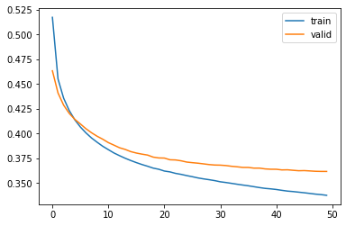

```python
# Capturing learning history per epoch
hist  = pd.DataFrame(history.history)
hist['epoch'] = history.epoch

# Plotting accuracy at different epochs
plt.plot(hist['loss'])
plt.plot(hist['val_loss'])
plt.legend(("train" , "valid") , loc =0)

#Printing results
results = model.evaluate(X_val, y_val)
```

```python
y_pred=model.predict(X_val)
y_pred = (y_pred > 0.5)
y_pred
```

```
array([[False],
       [False],
       [False],
       ...,
       [False],
       [False],
       [False]])
```

```python
def make_confusion_matrix(cf,
                          group_names=None,
                          categories='auto',
                          count=True,
                          percent=True,
                          cbar=True,
                          xyticks=True,
                          xyplotlabels=True,
                          sum_stats=True,
                          figsize=None,
                          cmap='Blues',
                          title=None):
    '''
    This function will make a pretty plot of an sklearn Confusion Matrix cm using a Seaborn heatmap visualization.
    Arguments
    '''


    # CODE TO GENERATE TEXT INSIDE EACH SQUARE
    blanks = ['' for i in range(cf.size)]

    if group_names and len(group_names)==cf.size:
        group_labels = ["{}\n".format(value) for value in group_names]
    else:
        group_labels = blanks

    if count:
        group_counts = ["{0:0.0f}\n".format(value) for value in cf.flatten()]
    else:
        group_counts = blanks

    if percent:
        group_percentages = ["{0:.2%}".format(value) for value in cf.flatten()/np.sum(cf)]
    else:
        group_percentages = blanks

    box_labels = [f"{v1}{v2}{v3}".strip() for v1, v2, v3 in zip(group_labels,group_counts,group_percentages)]
    box_labels = np.asarray(box_labels).reshape(cf.shape[0],cf.shape[1])


    # CODE TO GENERATE SUMMARY STATISTICS & TEXT FOR SUMMARY STATS
    if sum_stats:
        #Accuracy is sum of diagonal divided by total observations
        accuracy  = np.trace(cf) / float(np.sum(cf))



    # SET FIGURE PARAMETERS ACCORDING TO OTHER ARGUMENTS
    if figsize==None:
        #Get default figure size if not set
        figsize = plt.rcParams.get('figure.figsize')

    if xyticks==False:
        #Do not show categories if xyticks is False
        categories=False


    # MAKE THE HEATMAP VISUALIZATION
    plt.figure(figsize=figsize)
    sns.heatmap(cf,annot=box_labels,fmt="",cmap=cmap,cbar=cbar,xticklabels=categories,yticklabels=categories)


    if title:
        plt.title(title)
```

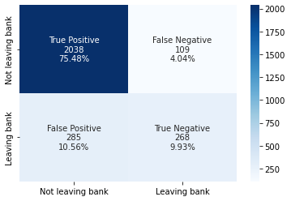

```python
#Calculating the confusion matrix
from sklearn.metrics import confusion_matrix
cm=confusion_matrix(y_val, y_pred)
labels = ['True Positive','False Negative','False Positive','True Negative']
categories = [ 'Not leaving bank','Leaving bank']
make_confusion_matrix(cm,
                      group_names=labels,
                      categories=categories,
                      cmap='Blues')
```

```python
#Accuracy as per the classification report
from sklearn import metrics
cr=metrics.classification_report(y_val,y_pred)
print(cr)
```

```
              precision    recall  f1-score   support

           0       0.88      0.95      0.91      2147
           1       0.71      0.48      0.58       553

    accuracy                           0.85      2700
   macro avg       0.79      0.72      0.74      2700
weighted avg       0.84      0.85      0.84      2700
```

##### Model 0 performnace is poor with a recall score of 0.48 (48%).

I will add layers to see if I can improve the model.